# praca domowa 7

Joanna Gajewska

11 June 2019

# Wstęp

W zadaniu będę wyznaczać najlepszą liczbę klastrów dla metod k-średnich i k-mediów

W pierwszej kolejności krótko opiszę powyższe metody

### Metoda k-średnich

Celem tej metody jest podział zbioru danych na k klastrów. Dobry podział to taki, w którym suma odległości obserwacji należących do klastra jest znacznie mniejsza od sumy odległości obserwacji pomiędzy klastrami. Metoda k-średnich polega na wyznaczeniu współrzędnych k punktów, które zostaną uznane za środki klastrów. Obserwacja będzie należała do tego klastra, którego środek jest najbliżej niej.

### Metoda k-mediów (metoda grupowania wokół centroidów - PAM Partitioning Around Medoid)

Metoda PAM działa na podobnej zasadzie jak k-średnich, z tą różnicą, że środkami klastrów są obserwacje ze zbioru danych. W metodzie PAM zbiór możliwych środków klastrów jest więc znacznie mniejszy, niż w metodzie k-średnich.

Do wyznaczenia najlepszej liczby klastrów będę korzsytać z biblioteki factoextra, która pozwala na wykreślenie wykresu z otymalną ilością klastrów jak i wizaualizacje klasteryzacji dla najlepszego podziału.

#### Metody jakie będę stostować do oszacowania optymalnej ilości klastrów to:

- metoda sylwetki -określa, jak dobrze każdy obiekt leży w swoim klastrze. Metoda średniej sylwetki oblicza średnią sylwetkę obserwacji dla różnych wartości k . Optymalna liczba klastrów k to ta, która maksymalizuje średnią sylwetkę w zakresie możliwych wartości dla k
- metoda łokcia - Całkowita suma kwadratowa w klastrze (wss) mierzy zwartość klastra i chcemy, aby była jak najmniejsza
- metoda statystyki luki - porównuje całkowitą zmienność wewnątrzklastra dla różnych wartości k z ich oczekiwanymi wartościami w zerowym rozkładzie odniesienia danych (tj. rozkład bez oczywistego grupowania). Zestaw danych referencyjnych jest generowany przy użyciu symulacji Monte Carlo procesu próbkowania.

Zbiór danych na jakim będę przeprowadzać klasteryzacje dotyczy rodzai win. Zawiera on 13 atrybutów + atrybut określający przynależność do danej klasy. Pierwotnie zbiór jest podzielony na 3 podzbiory.

```
##                      name    type na        mean        disp  median
## 1                   Klasa integer  0   1.9382022   0.7750350   2.000
## 2                 Alkohol numeric  0  13.0006180   0.8118265  13.050
## 3           Kwas_jabłkowy numeric  0   2.3363483   1.1171461   1.865
## 4                  Popiol numeric  0   2.3665169   0.2743440   2.360
## 5     Alkaicznosc_popiolu numeric  0  19.4949438   3.3395638  19.500
## 6                  Magnez integer  0  99.7415730  14.2824835  98.000
## 7        Calkowite_fenole numeric  0   2.2951124   0.6258510   2.355
## 8              Flawonoidy numeric  0   2.0292697   0.9988587   2.135
## 9  Nonflawanoidowe_fenole numeric  0   0.3618539   0.1244533   0.340
## 10          Proantocyjany numeric  0   1.5908989   0.5723589   1.555
## 11    Intensywnosc_koloru numeric  0   5.0580899   2.3182859   4.690
## 12                 Odcien numeric  0   0.9574494   0.2285716   0.965
## 13      Rozcienczenie_win numeric  0   2.6116854   0.7099904   2.780
## 14                Prolina integer  0 746.8932584 314.9074743 673.500
##           mad    min     max nlevs
## 1    1.482600   1.00    3.00     0
## 2    1.008168  11.03   14.83     0
## 3    0.770952   0.74    5.80     0
## 4    0.237216   1.36    3.23     0
## 5    3.039330  10.60   30.00     0
## 6   14.826000  70.00  162.00     0
## 7    0.748713   0.98    3.88     0
## 8    1.237971   0.34    5.08     0
## 9    0.126021   0.13    0.66     0
## 10   0.563388   0.41    3.58     0
## 11   2.238726   1.28   13.00     0
## 12   0.244629   0.48    1.71     0
## 13   0.770952   1.27    4.00     0
## 14 300.226500 278.00 1680.00     0
```

### K-średnich

#### Metoda sylwetki

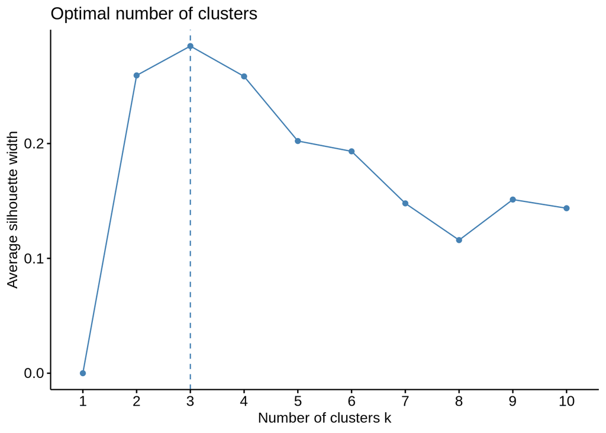

#### Metoda łokcia

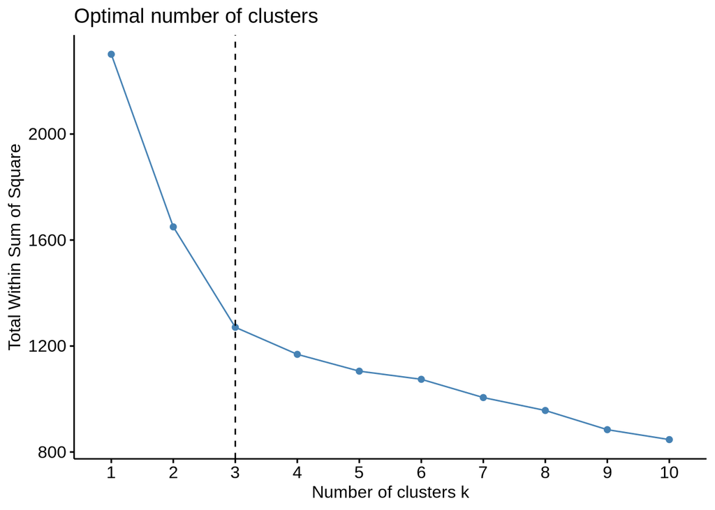

#### Metoda statystyki luki

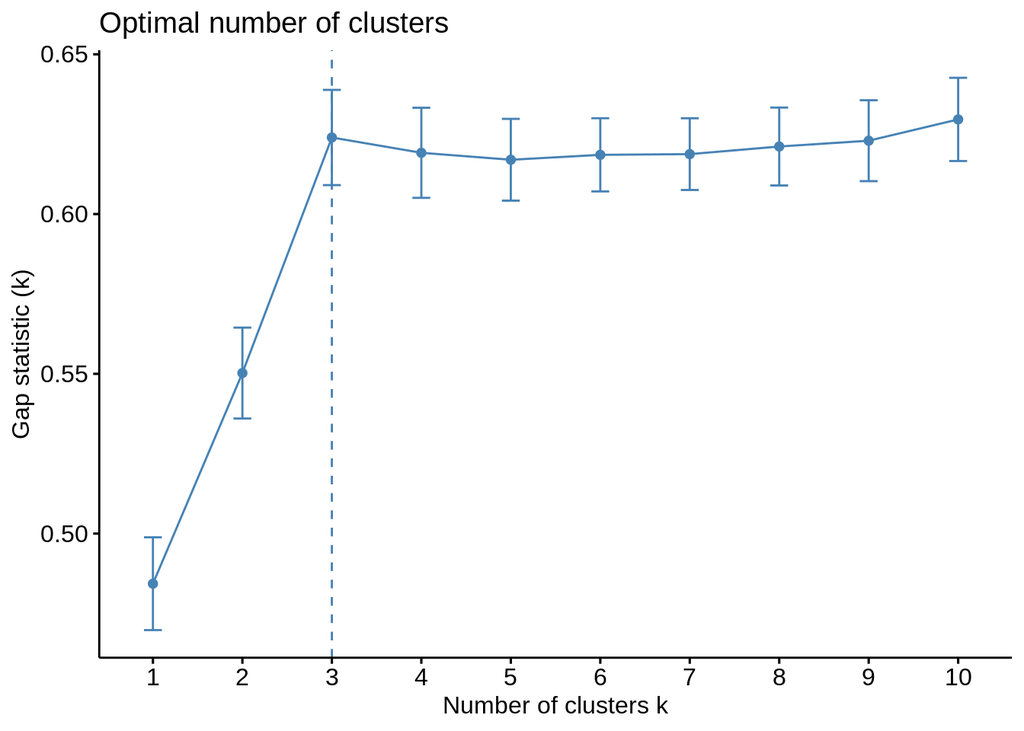

Jak widać na powyższych wykresach, dla metody k-średnich wszystkie meody wyznaczania optymalnej liczby klastrów dają ten sam rezultat - podział na 3 grupy. Jest on jak najbardziej prawidłowy, gdyż pierwotny zbiór również jest sklasyfikowany na tyle podzbiorów.

# K-mediów

#### Metoda sylwetki

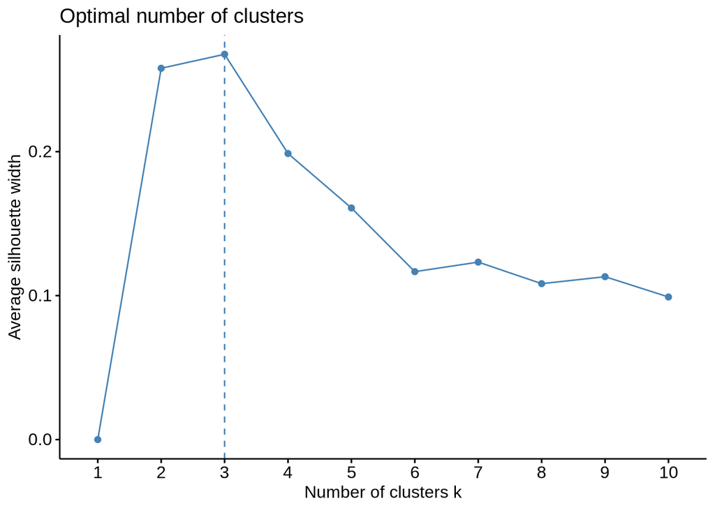

#### Metoda łokcia

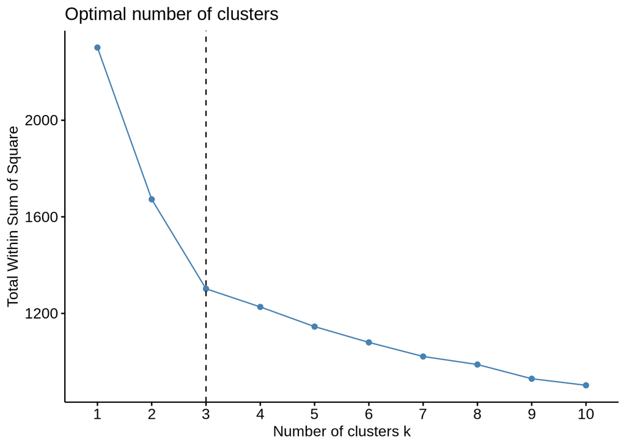

#### Metoda statystyki luki

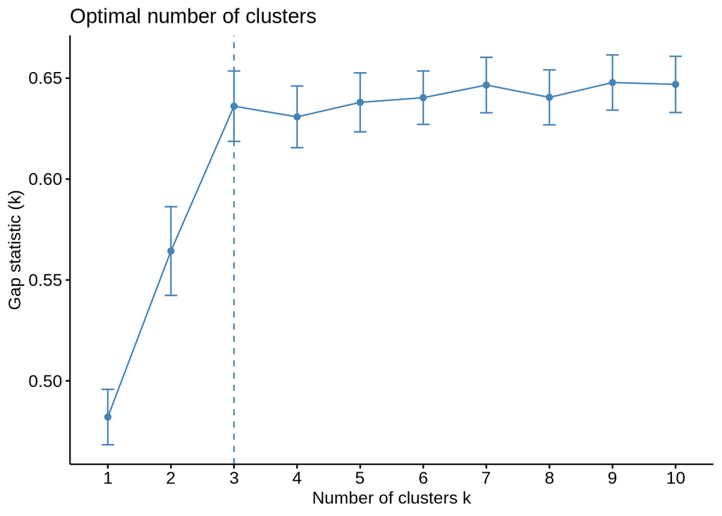

w przypadku metody k-mediów efekty są niemal identyczne. Ksztalt wykresów względem tych wykreślonych dla k-średnich prawie niczym się nie różni. Oczywiście liczba klastrów wyznaczona dla metody k-mediów jest taka sama jak w poprzednim przypadku- 3 grupy to najbardziej optymalny podział.

## Klastry dla ich optymalnej liczby

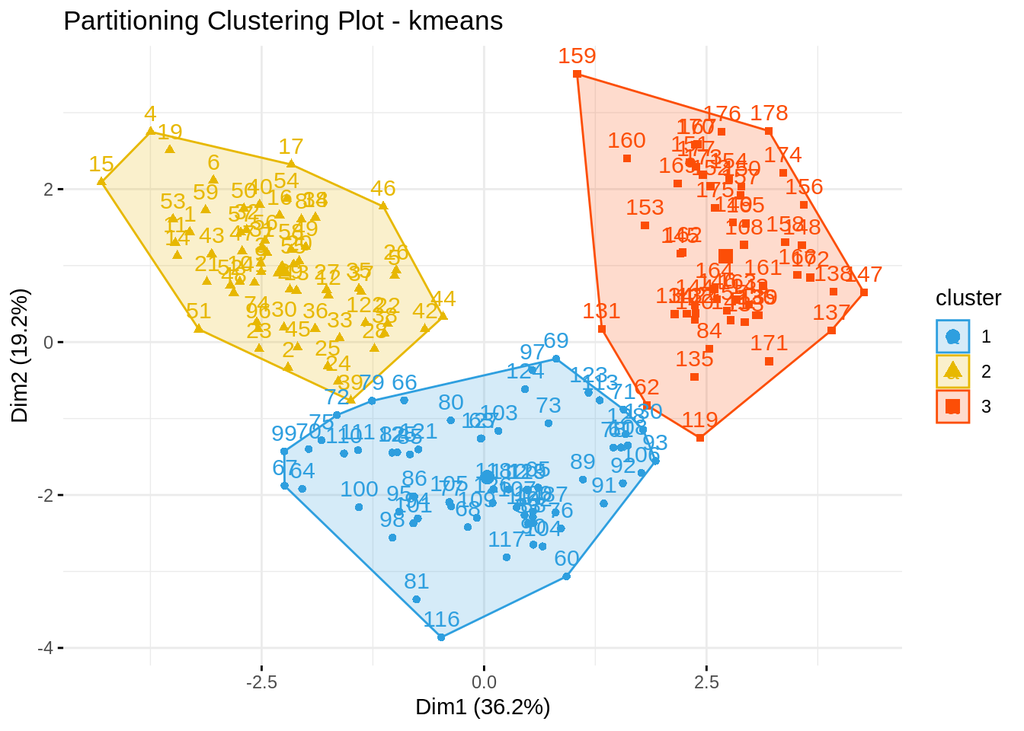

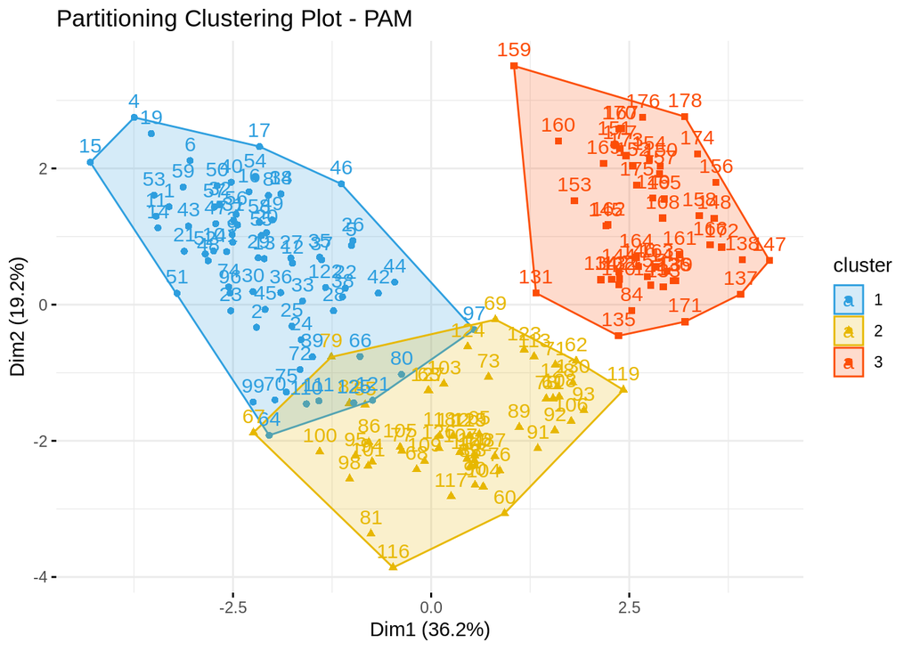

Jak widać na powyższych dwóch wizualizacjach grupowanie obserwacji jest podobne dla k-średnich i k-mediów. Występują jednak pewne różnice. Jeden z klastrów dla metody k - mediów jest nieco bardziej “obszerny” niż ten odpowiadający drugiej metodzie.

# Centra klastów

## k-średnich

```
##      Alkohol Kwas_jabłkowy     Popiol Alkaicznosc_popiolu      Magnez
## 1 -0.9234669    -0.3929331 -0.4931257           0.1701220 -0.49032869
## 2  0.8328826    -0.3029551  0.3636801          -0.6084749  0.57596208
## 3  0.1644436     0.8690954  0.1863726           0.5228924 -0.07526047
##   Calkowite_fenole  Flawonoidy Nonflawanoidowe_fenole Proantocyjany
## 1      -0.07576891  0.02075402            -0.03343924    0.05810161
## 2       0.88274724  0.97506900            -0.56050853    0.57865427
## 3      -0.97657548 -1.21182921             0.72402116   -0.77751312
##   Intensywnosc_koloru     Odcien Rozcienczenie_win    Prolina
## 1          -0.8993770  0.4605046         0.2700025 -0.7517257
## 2           0.1705823  0.4726504         0.7770551  1.1220202
## 3           0.9388902 -1.1615122        -1.2887761 -0.4059428
```

## k-mediów

```
##         Alkohol Kwas_jabłkowy      Popiol Alkaicznosc_popiolu      Magnez
## [1,]  0.5904981    -0.4711544  0.15849862           0.3009543  0.01809398
## [2,] -0.9246039    -0.5427655 -0.89856839          -0.1482061 -1.38222271
## [3,]  0.3934117     0.8088930  0.04914686           0.6003946 -0.54203270
##      Calkowite_fenole    Flawonoidy Nonflawanoidowe_fenole Proantocyjany
## [1,]        0.6469393  0.9518166597            -0.81841060    0.47016154
## [2,]       -1.0307762  0.0007311716             0.06545479    0.06831575
## [3,]       -0.5833854 -1.2707199546             0.70826598   -0.59560339
##      Intensywnosc_koloru     Odcien Rozcienczenie_win    Prolina
## [1,]          0.01807806  0.3611585         1.2089101  0.5497067
## [2,]         -0.71522236  0.1861586         0.7863692 -0.7522631
## [3,]          1.45017064 -1.7825902        -1.3967588 -0.3076880
```

Jak widać centra dla większości atrybutów są zbliżone dla obu metod. Jednak już z wizualizacji podziału na grupy widać, że jeden podzbiór jest nieco inaczej zdefiniowany w obu przypdkach. Z tego też wynikają większe różnice w wyznaczeniu centrów odpowiadające tym dwum klastrom.